# Course Project - Practical Machine Learning: How Well Do People Exercise?

Using devices such as Jawbone Up, Nike FuelBand, and Fitbit it is now possible to collect a large amount of data about personal activity relatively inexpensively. These type of devices are part of the quantified self movement – a group of enthusiasts who take measurements about themselves regularly to improve their health, to find patterns in their behavior, or because they are tech geeks. One thing that people regularly do is quantify how much of a particular activity they do, but they rarely quantify how well they do it. In this project, your goal will be to use data from accelerometers on the belt, forearm, arm, and dumbell of 6 participants. They were asked to perform barbell lifts correctly and incorrectly in 5 different ways. More information is available from the website here: http://web.archive.org/web/20161224072740/http:/groupware.les.inf.puc-rio.br/har (see the section on the Weight Lifting Exercise Dataset).

## Setup

Before starting the analysis, it is important to clean up the environment, set the right working directory and load the packages you need for the analysis.

```r
rm(list=ls())
getwd()
```

```
## [1] "/Users/minheelee/Documents/1st year/Econometrics/R/Practical Machine Learning"
```

```r
setwd("~/Documents/1st year/Econometrics/R/Practical Machine Learning")

library(knitr)
library(caret)
```

```r
library(rpart)
library(rpart.plot)
library(rattle)
library(randomForest)
library(corrplot)
```

## Downloading and Loading the Data

The codes below download the file directly from the url.

```r
urltrain <- "https://d396qusza40orc.cloudfront.net/predmachlearn/pml-training.csv"
urltest <- "https://d396qusza40orc.cloudfront.net/predmachlearn/pml-testing.csv"

download.file(urltrain, destfile="train.csv", method="curl")
download.file(urltest, destfile="test.csv", method="curl")
```

Then, we can read in the data to the environment.

```r
train <- read.csv("train.csv", header=TRUE)
test <- read.csv("test.csv", header=TRUE)
```

The loaded dataset looks like this.

```r
head(train)
```

```
##   X user_name raw_timestamp_part_1 raw_timestamp_part_2   cvtd_timestamp
## 1 1  carlitos           1323084231               788290 05/12/2011 11:23
## 2 2  carlitos           1323084231               808298 05/12/2011 11:23
## 3 3  carlitos           1323084231               820366 05/12/2011 11:23
## 4 4  carlitos           1323084232               120339 05/12/2011 11:23
## 5 5  carlitos           1323084232               196328 05/12/2011 11:23
## 6 6  carlitos           1323084232               304277 05/12/2011 11:23
##   new_window num_window roll_belt pitch_belt yaw_belt total_accel_belt
## 1         no         11      1.41       8.07    -94.4                3
## 2         no         11      1.41       8.07    -94.4                3
## 3         no         11      1.42       8.07    -94.4                3
## 4         no         12      1.48       8.05    -94.4                3
## 5         no         12      1.48       8.07    -94.4                3
## 6         no         12      1.45       8.06    -94.4                3
##   kurtosis_roll_belt kurtosis_picth_belt kurtosis_yaw_belt skewness_roll_belt
```

[output cut: 251 more lines]

```r
head(test)
```

```
##   X user_name raw_timestamp_part_1 raw_timestamp_part_2   cvtd_timestamp
## 1 1     pedro           1323095002               868349 05/12/2011 14:23
## 2 2    jeremy           1322673067               778725 30/11/2011 17:11
## 3 3    jeremy           1322673075               342967 30/11/2011 17:11
## 4 4    adelmo           1322832789               560311 02/12/2011 13:33
## 5 5    eurico           1322489635               814776 28/11/2011 14:13
## 6 6    jeremy           1322673149               510661 30/11/2011 17:12
##   new_window num_window roll_belt pitch_belt yaw_belt total_accel_belt
## 1         no         74    123.00      27.00    -4.75               20
## 2         no        431      1.02       4.87   -88.90                4
## 3         no        439      0.87       1.82   -88.50                5
## 4         no        194    125.00     -41.60   162.00               17
## 5         no        235      1.35       3.33   -88.60                3
## 6         no        504     -5.92       1.59   -87.70                4
##   kurtosis_roll_belt kurtosis_picth_belt kurtosis_yaw_belt skewness_roll_belt
```

[output cut: 251 more lines]

## Data Processing

As the first step, we divide the train datset into two partitions using the classe variable with the training dataset containing 70% of the observations. Also, setting the seed is important for reproducibility of this analysis.

```r
set.seed(111)

traincut  <- createDataPartition(train$classe, p=0.7, list=FALSE)
trainingset <- train[traincut, ]
testingset  <- train[-traincut, ]
```

With the nearZeroVar function, I removed the variables that contain close-to-zero variance, as it is likely that it is not helpful for the analysis.

```r
nzv <- nearZeroVar(trainingset)
trainingset <- trainingset[, -nzv]
testingset <- testingset[, -nzv]
```

Furthermore, I get rid of the variables whose values are NA for more than 95% of the observations.

```r
na <- sapply(trainingset, function(x) mean(is.na(x))) > 0.95
trainingset <- trainingset[, na==FALSE]
testingset  <- testingset[, na==FALSE]
```

Lastly, I also drop the first five variables that are mostly for identification of the subject.

```r
trainingset <- trainingset[, -(1:5)]
testingset  <- testingset[, -(1:5)]
```

## Analysis

1. Random Forest Model

The first model I used is the Random Forest Model, and I also report the confusion matrix of the predicitons using the model and a bar plot showing the accuracy of the predictions.

```r
set.seed(111)
control_rf <- trainControl(method="cv", number=3, verboseIter=FALSE)
model_rf <- train(classe ~ ., data=trainingset, method="rf",
                  trControl=control_rf)
model_rf$finalModel
```

```
##
## Call:
##  randomForest(x = x, y = y, mtry = param$mtry)
##                Type of random forest: classification
##                      Number of trees: 500
## No. of variables tried at each split: 27
##
##         OOB estimate of  error rate: 0.29%
## Confusion matrix:
##      A    B    C    D    E  class.error
## A 3903    1    0    1    1 0.0007680492
## B    8 2648    2    0    0 0.0037622272
## C    0    5 2390    1    0 0.0025041736
## D    0    0   14 2238    0 0.0062166963
## E    0    0    0    7 2518 0.0027722772
```

```r
prediction_rf <- predict(model_rf, newdata=testingset)
confusionmat_rf <- confusionMatrix(prediction_rf, as.factor(testingset$classe))
confusionmat_rf
```

```
## Confusion Matrix and Statistics
##
##           Reference
## Prediction    A    B    C    D    E
##          A 1674    2    0    0    0
##          B    0 1136    2    0    2
##          C    0    1 1024    1    0
##          D    0    0    0  963    5
##          E    0    0    0    0 1075
##
## Overall Statistics
##
##                Accuracy : 0.9978
##                  95% CI : (0.9962, 0.9988)
##     No Information Rate : 0.2845
##     P-Value [Acc > NIR] : < 2.2e-16
##
##                   Kappa : 0.9972
##
##  Mcnemar's Test P-Value : NA
##
## Statistics by Class:
##
##                      Class: A Class: B Class: C Class: D Class: E
## Sensitivity            1.0000   0.9974   0.9981   0.9990   0.9935
## Specificity            0.9995   0.9992   0.9996   0.9990   1.0000
## Pos Pred Value         0.9988   0.9965   0.9981   0.9948   1.0000
## Neg Pred Value         1.0000   0.9994   0.9996   0.9998   0.9985
## Prevalence             0.2845   0.1935   0.1743   0.1638   0.1839
## Detection Rate         0.2845   0.1930   0.1740   0.1636   0.1827
## Detection Prevalence   0.2848   0.1937   0.1743   0.1645   0.1827
## Balanced Accuracy      0.9998   0.9983   0.9988   0.9990   0.9968
```

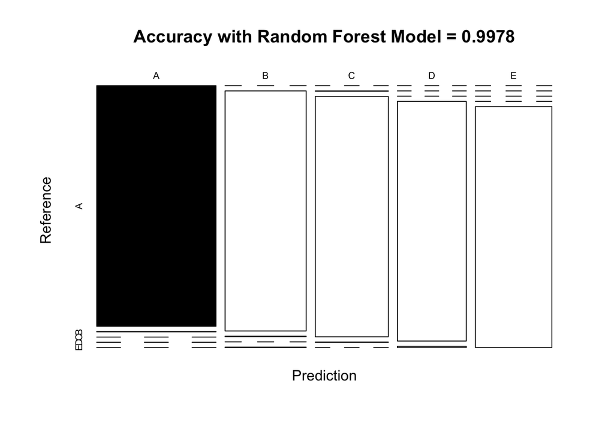

```r
plot(confusionmat_rf$table, col = confusionmat_rf$byClass,
     main = paste("Accuracy with Random Forest Model =",
                  round(confusionmat_rf$overall['Accuracy'], 4)))
```

2. Decision Tree Model

Now I fit the data with the decision tree model.

[figure not shown]

```r
set.seed(111)
model_dt <- rpart(classe ~ ., data=trainingset, method="class")
fancyRpartPlot(model_dt)
```

```r
prediction_dt <- predict(model_dt, newdata=testingset, type="class")
confusionmat_dt <- confusionMatrix(prediction_dt, as.factor(testingset$classe))
confusionmat_dt
```

```
## Confusion Matrix and Statistics
##
##           Reference
## Prediction    A    B    C    D    E
##          A 1547  270   16   92   57
##          B   45  651   75   51  102
##          C   14   89  839   85   61
##          D   58   95   80  670  136
##          E   10   34   16   66  726
##
## Overall Statistics
##
##                Accuracy : 0.7533
##                  95% CI : (0.742, 0.7642)
##     No Information Rate : 0.2845
##     P-Value [Acc > NIR] : < 2.2e-16
##
##                   Kappa : 0.6861
##
##  Mcnemar's Test P-Value : < 2.2e-16
##
## Statistics by Class:
##
##                      Class: A Class: B Class: C Class: D Class: E
## Sensitivity            0.9241   0.5716   0.8177   0.6950   0.6710
## Specificity            0.8967   0.9425   0.9488   0.9250   0.9738
## Pos Pred Value         0.7805   0.7045   0.7711   0.6449   0.8521
## Neg Pred Value         0.9675   0.9016   0.9610   0.9393   0.9293
## Prevalence             0.2845   0.1935   0.1743   0.1638   0.1839
## Detection Rate         0.2629   0.1106   0.1426   0.1138   0.1234
## Detection Prevalence   0.3368   0.1570   0.1849   0.1766   0.1448
## Balanced Accuracy      0.9104   0.7570   0.8832   0.8100   0.8224
```

[figure not shown]

```r
plot(confusionmat_dt$table, col = confusionmat_dt$byClass,
     main = paste("Accuracy with Random Forest Model =",
                  round(confusionmat_dt$overall['Accuracy'], 4)))
```